# Actividad 1.1 Normalidad univariada. Transformaciones para normalidad_A01709445

### Primera distribuciónn

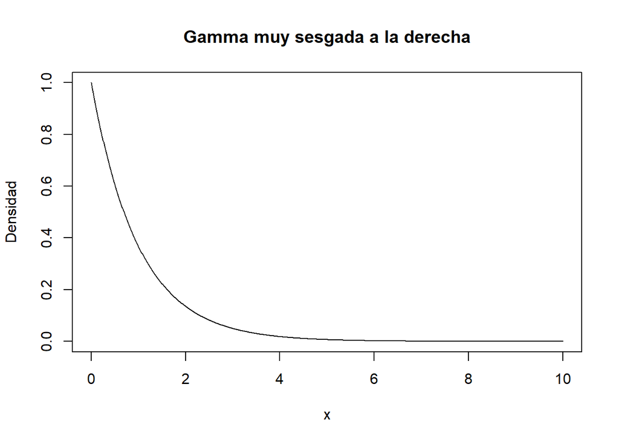

```r
x = seq(0, 10, by = 0.01)

Pob_gamma1 = dgamma(x, shape = 1, rate = 1)


plot(x, Pob_gamma1,
     type = "l",
     main = "Gamma muy sesgada a la derecha",
     xlab = "x",
     ylab = "Densidad")
```

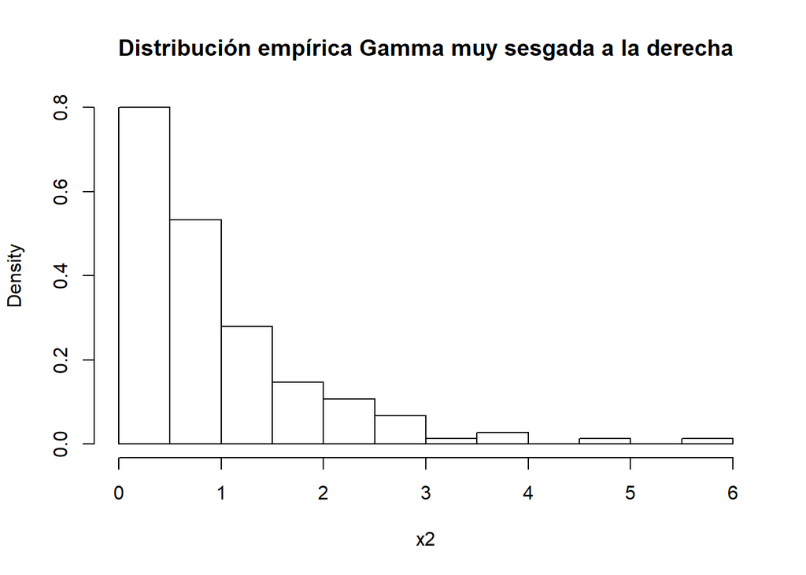

```r
x2 = rgamma(150, shape = 1, rate = 1)

hist(x2,
     col = 0,
     main = "Distribución empírica Gamma muy sesgada a la derecha",
     freq = FALSE)
```

```r
sg2 = skewness(x2)
k2 = kurtosis(x2)

sg2
```

```
## [1] 2.081097
```

```r
k2
```

```
## [1] 9.141988
```

```r
jarque.test(x2)
```

```
##
##  Jarque-Bera Normality Test
##
## data:  x2
## JB = 344.05, p-value < 2.2e-16
## alternative hypothesis: greater
```

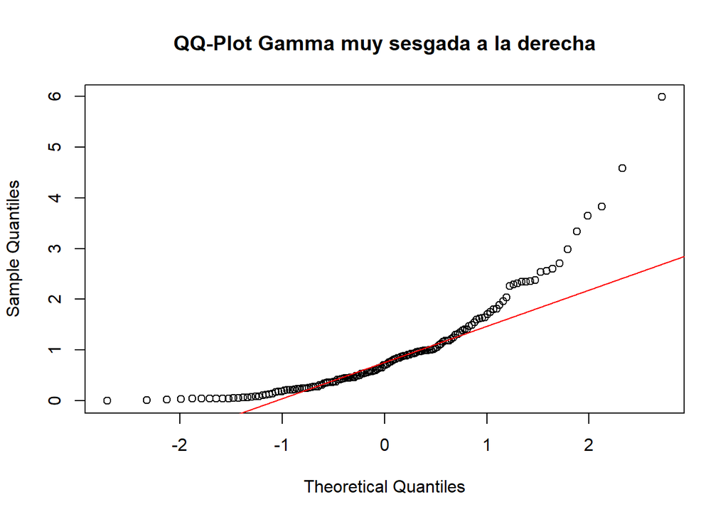

```r
qqnorm(x2, main = "QQ-Plot Gamma muy sesgada a la derecha")
qqline(x2, col = "red")
```

### Segunda distribución

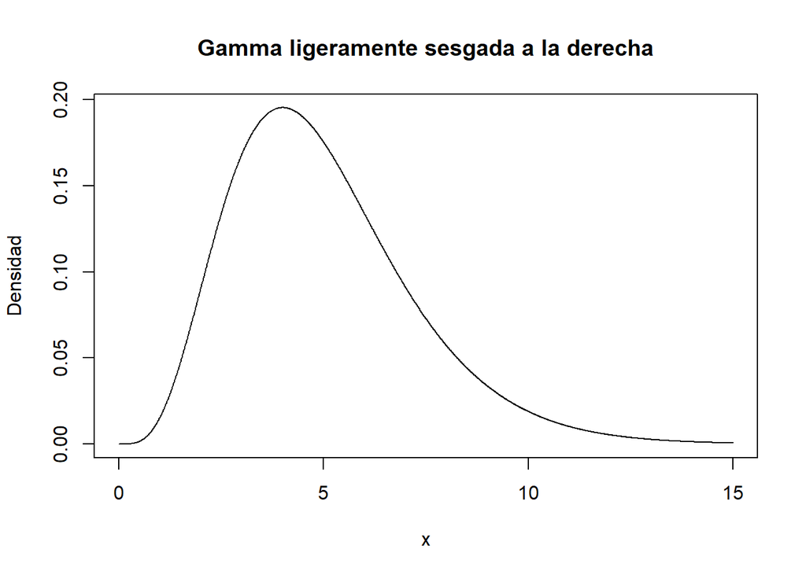

```r
x = seq(0, 15, by = 0.01)

Pob_gamma2 = dgamma(x, shape = 5, rate = 1)

plot(x, Pob_gamma2,
     type = "l",
     main = "Gamma ligeramente sesgada a la derecha",
     xlab = "x",
     ylab = "Densidad")
```

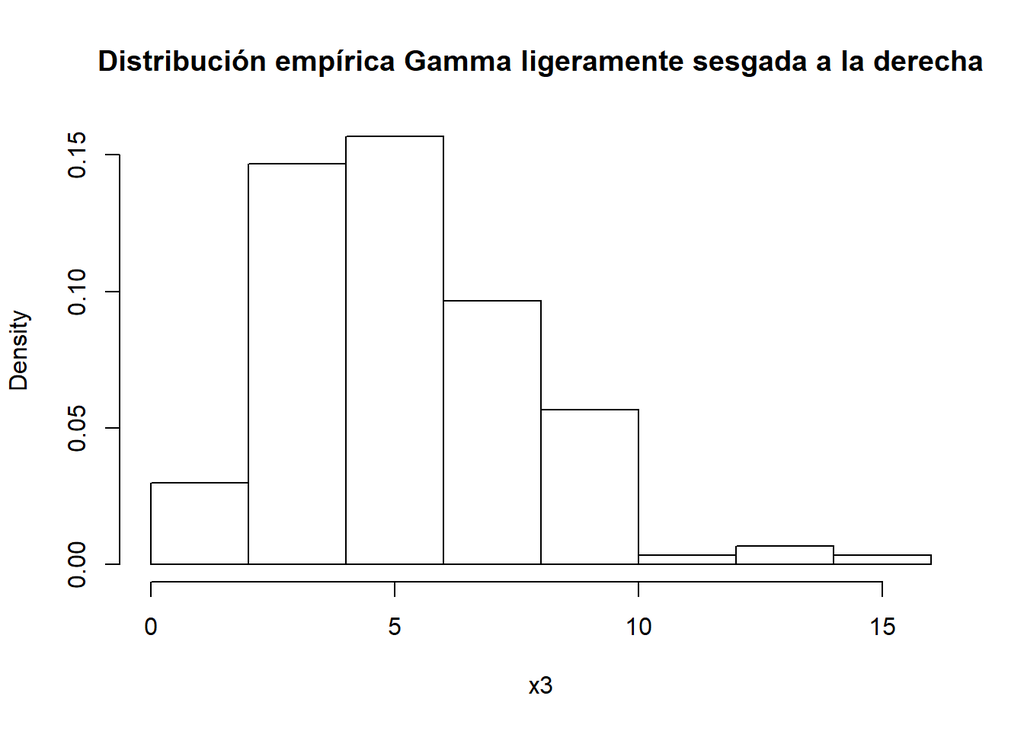

```r
x3 = rgamma(150, shape = 5, rate = 1)

hist(x3,
     col = 0,
     main = "Distribución empírica Gamma ligeramente sesgada a la derecha",
     freq = FALSE)
```

```r
sg3 = skewness(x3)
k3 = kurtosis(x3)

sg3
```

```
## [1] 0.9276645
```

```r
k3
```

```
## [1] 4.361977
```

```r
jarque.test(x3)
```

```
##
##  Jarque-Bera Normality Test
##
## data:  x3
## JB = 33.108, p-value = 6.468e-08
## alternative hypothesis: greater
```

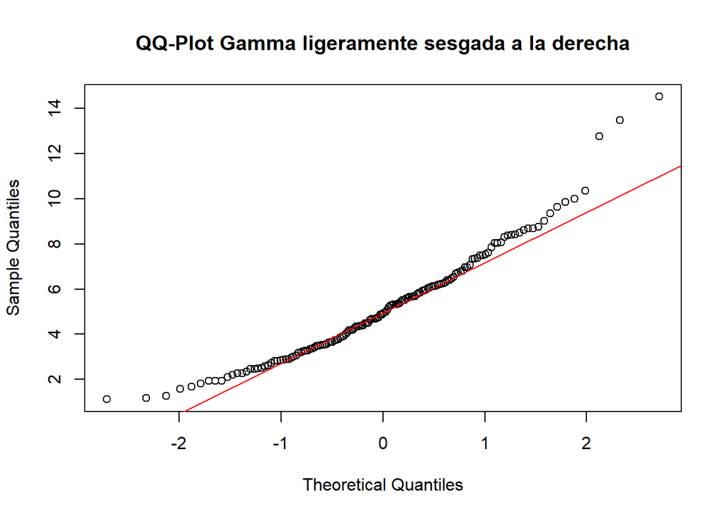

```r
qqnorm(x3, main = "QQ-Plot Gamma ligeramente sesgada a la derecha")
qqline(x3, col = "red")
```

### Tercera distribución

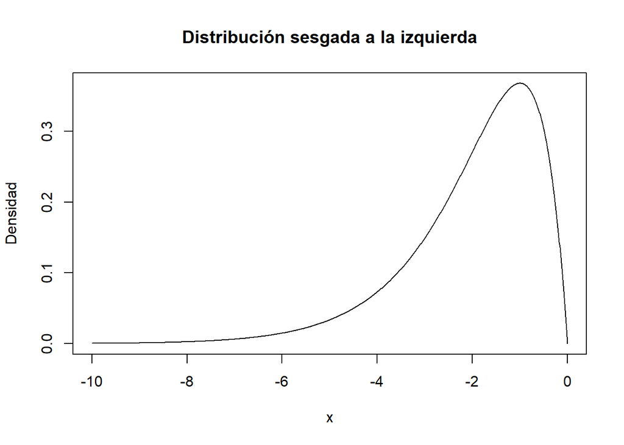

```r
x = seq(-10, 0, by = 0.01)

Pob_gamma3 = dgamma(-x, shape = 2, rate = 1)

plot(x, Pob_gamma3,
     type = "l",
     main = "Distribución sesgada a la izquierda",
     xlab = "x",
     ylab = "Densidad")
```

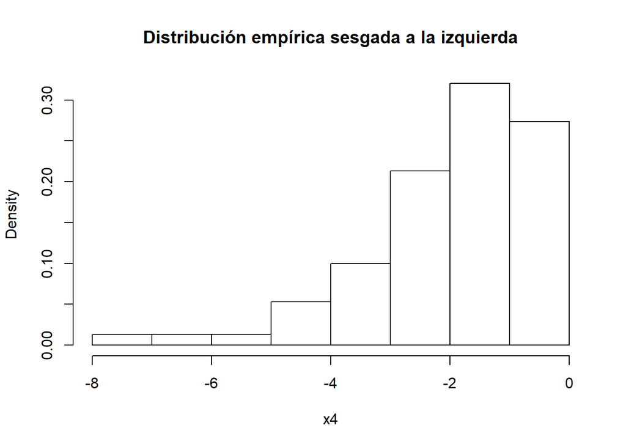

```r
x4 = -rgamma(150, shape = 2, rate = 1)

hist(x4,
     col = 0,
     main = "Distribución empírica sesgada a la izquierda",
     freq = FALSE)
```

```r
sg4 = skewness(x4)
k4 = kurtosis(x4)

sg4
```

```
## [1] -1.417767
```

```r
k4
```

```
## [1] 5.500313
```

```r
jarque.test(x4)
```

```
##
##  Jarque-Bera Normality Test
##
## data:  x4
## JB = 89.324, p-value < 2.2e-16
## alternative hypothesis: greater
```

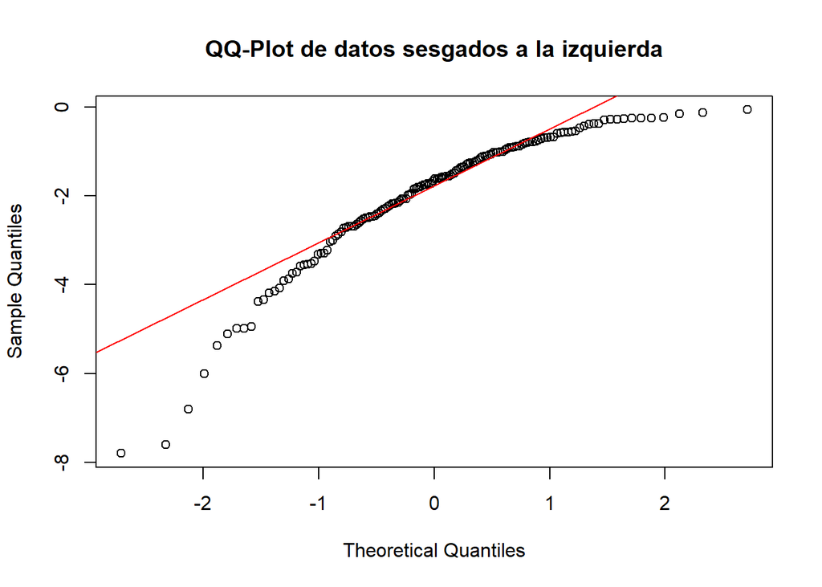

```r
qqnorm(x4, main = "QQ-Plot de datos sesgados a la izquierda")
qqline(x4, col = "red")
```

3. Emite una conclusión de cómo se relaciona la curtosis y el sesgo con la distribución QQPlot y con la prueba de hipótesis de Jarque-Bera.

   La curtosis y el sesgo ayudan a ver que tan diferente es una distribución a comparacion de una normal. Si el sesgo se aleja de 0 o la curtosis se aleja de 3 entonces los puntos del QQ plot tienen a separarse de la linea recta. Jarque Bera también utiliza sesgo y curtosis por lo que también afecta y esta tiene a producr p values más pequeños lo que hace que el test sea más propenso a rechazar que la distribución es normal